# R Code Corresponding to the Book *The Handbook of Research Synthesis and Meta-Analysis* by Cooper et al. (2019)

```r
# var-cov matrix of the random effects (values below diagonal are correlations)
# note: the T-hat matrix given in the chapter (p. 354) is in a different order

G <- res$G
G[lower.tri(G)] <- cov2cor(G)[lower.tri(G)]
round(G, digits=2)
```

```
##           acog.perf asom.perf conf.perf acog.asom acog.conf asom.conf
## acog.perf      0.13      0.08     -0.04      0.01     -0.02      0.01
## asom.perf      0.88      0.06     -0.04      0.01     -0.02      0.00
## conf.perf     -0.45     -0.64      0.06     -0.01      0.02     -0.01
## acog.asom      0.34      0.58     -0.99      0.00      0.00      0.00
## acog.conf     -0.50     -0.72      0.68     -0.71      0.01      0.00
## asom.conf      0.20      0.06     -0.64      0.59     -0.11      0.01
```

```r
# restructure estimated mean correlations into a 4x4 matrix

R <- vec2mat(coef(res), dimnames=c("perf", "acog", "asom", "conf"))
round(R, digits=3)
```

```
##        perf   acog   asom   conf
## perf  1.000 -0.034 -0.071  0.233
## acog -0.034  1.000  0.544 -0.453
## asom -0.071  0.544  1.000 -0.397
## conf  0.233 -0.453 -0.397  1.000
```

```r
# var-cov matrix of the estimated mean correlations

round(vcov(res), digits=4)
```

```
##             v.acog.perf v.asom.perf v.conf.perf v.acog.asom v.acog.conf v.asom.conf
## v.acog.perf      0.0150      0.0089     -0.0048      0.0004     -0.0016      0.0008
## v.asom.perf      0.0089      0.0081     -0.0049      0.0007     -0.0019      0.0004
## v.conf.perf     -0.0048     -0.0049      0.0085     -0.0012      0.0020     -0.0016
## v.acog.asom      0.0004      0.0007     -0.0012      0.0011     -0.0007     -0.0001
## v.acog.conf     -0.0016     -0.0019      0.0020     -0.0007      0.0027      0.0005
## v.asom.conf      0.0008      0.0004     -0.0016     -0.0001      0.0005      0.0020
```

```r
# fit regression model with 'conf' as outcome and 'acog' and 'asom' as predictors

fit1 <- matreg(4, 2:3, R=R, V=vcov(res))
dfround(fit1$tab[1:4], digits=c(2,3,2,3))
```

```
##       beta    se  zval  pval
## acog -0.34 0.074 -4.55 0.000
## asom -0.21 0.070 -3.05 0.002
```

```r
# fit regression model with 'perf' as outcome and 'acog', 'asom', and 'conf' as predictors

fit2 <- matreg(1, 2:4, R=R, V=vcov(res))
dfround(fit2$tab[1:4], digits=c(2,3,2,3))
```

```
##       beta    se  zval  pval
## acog  0.10 0.143  0.68 0.496
## asom -0.02 0.073 -0.23 0.819
## conf  0.27 0.105  2.59 0.010
```

```r
# variance explained in sport performance by the three subscales

round(fit2$R2 * 100, digits=2)
```

```
## [1] 6.08
```

```r
# install the 'igraph' package (if it is not already installed) and load it

if (!require(igraph)) {
   install.packages("igraph")
   library(igraph)
}
```

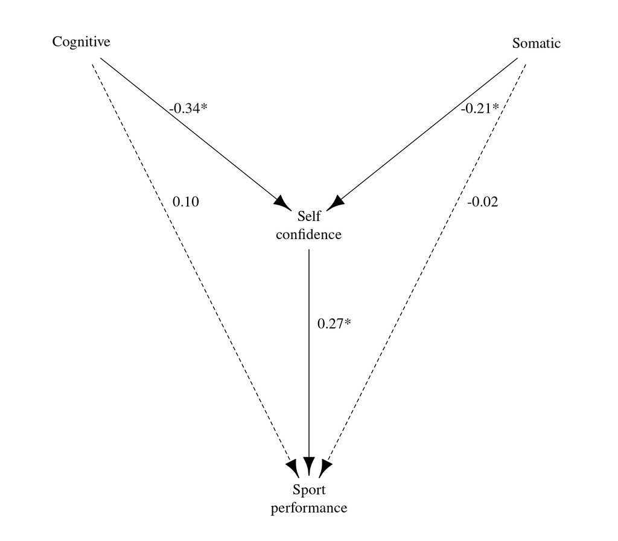

```r
# Figure 16.4: Random-Effects Path Coefficients for Prediction of Sport Performance

B <- R
B[,] <- 0
B[2:3,4] <- fit1$tab$beta
B[2:4,1] <- fit2$tab$beta
P <- B
P[,] <- 1
P[2:3,4] <- fit1$tab$pval
P[2:4,1] <- fit2$tab$pval

g <- graph_from_adjacency_matrix(B, mode="directed", weighted=TRUE)
vertex_attr(g, "name") <- c("Sport\nperformance", "Cognitive",
                            "Somatic", "Self\nconfidence")
L <- matrix(c(0,0, -1,2, 1,2, 0,1.2), nrow=4, ncol=2, byrow=TRUE)
par(mar=c(0,0,0,0))
plot(g, layout=L,
     edge.color = "black", edge.label.color = "black",
     vertex.color = "black", vertex.label.color = "black",
     vertex.shape = "none", vertex.size = 20,
     edge.label = paste0("              ", fmtx(t(B)[t(B) != 0], 2),
                         ifelse(t(P)[t(B) != 0] <= 0.05, "*", "")),
     edge.lty   = ifelse(t(P)[t(B) != 0] <= 0.05, "solid", "dashed"))
```

```r
# moderator analysis (subgroup by sport type)

dat.T <- dat[dat$sport == "T",]

res <- rma(ri, 0, weights=ni, mods = ~ v. - 1, data=dat.T, method="FE")
options(na.action = "na.pass")
dat.T$fit <- fitted(res)
options(na.action = "na.omit")

tmp <- rcalc(fit ~ var1 + var2 | study, ni=ni+1, data=dat.T)
V.T <- tmp$V

res.T <- rma.mv(ri, V.T, mods = ~ v. - 1, random = ~ v. | study, struct="UN", data=dat.T)

R.T <- R
R.T[lower.tri(R.T)] <- coef(res.T)

fit.T <- matreg(1, 2:4, R=R.T, V=vcov(res.T))

dat.I <- dat[dat$sport == "I",]

res <- rma(ri, 0, weights=ni, mods = ~ v. - 1, data=dat.I, method="FE")
options(na.action = "na.pass")
dat.I$fit <- fitted(res)
options(na.action = "na.omit")

tmp <- rcalc(fit ~ var1 + var2 | study, ni=ni+1, data=dat.I)
V.I <- tmp$V

res.I <- rma.mv(ri, V.I, mods = ~ v. - 1, random = ~ v. | study, struct="UN", data=dat.I)

R.I <- R
R.I[lower.tri(R.I)] <- coef(res.I)

fit.I <- matreg(1, 2:4, R=R.I, V=vcov(res.I))
```

```r
# show results for team sports

dfround(fit.T$tab[1:4], digits=c(2,3,2,3))
```

```
##       beta    se  zval  pval
## acog  0.18 0.285  0.63 0.527
## asom -0.09 0.091 -1.00 0.319
## conf  0.28 0.208  1.34 0.179
```

```r
# show results for individual sports

dfround(fit.I$tab[1:4], digits=c(2,3,2,3))
```

```
##      beta    se zval  pval
## acog 0.09 0.200 0.44 0.660
## asom 0.03 0.128 0.24 0.808
## conf 0.30 0.144 2.10 0.036
```

```r
# var-cov matrix of coefficients for team sports

round(fit.T$vb, digits=4)
```

```
##        acog   asom   conf
## acog 0.0813 0.0112 0.0515
## asom 0.0112 0.0082 0.0106
## conf 0.0515 0.0106 0.0431
```

```r
# var-cov matrix of coefficients for individual sports

round(fit.I$vb, digits=4)
```

```
##         acog    asom   conf
## acog  0.0399 -0.0073 0.0107
## asom -0.0073  0.0163 0.0037
## conf  0.0107  0.0037 0.0208
```

```r
# Wald-type test of the difference in slopes of conf -> perf

rma(yi = c(fit.I$tab["conf", "beta"], fit.T$tab["conf", "beta"]),
    vi = c(fit.I$tab["conf", "se"],   fit.T$tab["conf", "se"])^2,
    mods = c(0,1), method = "FE", digits = 3)
```

```
## Fixed-Effects with Moderators Model (k = 2)
##
## I^2 (residual heterogeneity / unaccounted variability): 0.00%
## H^2 (unaccounted variability / sampling variability):   1.00
## R^2 (amount of heterogeneity accounted for):            NA%
##
## Test for Residual Heterogeneity:
## QE(df = 0) = 0.000, p-val = 1.000
##
## Test of Moderators (coefficient 2):
## QM(df = 1) = 0.009, p-val = 0.925
##
## Model Results:
##
##          estimate     se    zval   pval   ci.lb  ci.ub
## intrcpt     0.303  0.144   2.098  0.036   0.020  0.586  *
## mods       -0.024  0.253  -0.094  0.925  -0.519  0.472
##
## ---
## Signif. codes:  0 '***' 0.001 '**' 0.01 '*' 0.05 '.' 0.1 ' ' 1
```

```r
# note: z=-0.094 differs from value in chapter (-0.079) due to rounding
```

```r
# compute matrix with partial correlations based on R

invR <- solve(R)
Rp <- -diag(diag(1/sqrt(invR))) %*% invR %*% diag(diag(1/sqrt(invR)))
round(Rp, digits=3)
```

```
##        [,1]   [,2]   [,3]   [,4]
## [1,] -1.000  0.080 -0.014  0.237
## [2,]  0.080 -1.000  0.445 -0.317
## [3,] -0.014  0.445 -1.000 -0.193
## [4,]  0.237 -0.317 -0.193 -1.000
```

```r
# compute partial correlations for each study individually

Ri <- lapply(split(dat, dat$study), function(x) {
   if (anyNA(x$ri)) {
      NULL
   } else {
      R <- vec2mat(x$ri)
      attr(R, "ni") <- x$ni[1]
      R
   }
})
Ri <- Ri[!sapply(Ri, is.null)]

dat.rp <- lapply(Ri, function(x) {
   invRi <- solve(x)
   rp <- -invRi[1,4] / sqrt(invRi[1,1] * invRi[4,4])
   vrp <- (1-rp^2)^2 / (attributes(x)$ni-3-1)
   data.frame(n=attributes(x)$ni, rp=rp, vrp=vrp)
})
dat.rp <- do.call(rbind, dat.rp)

dfround(dat.rp, digits=c(0,3,4))
```

```
##      n     rp    vrp
## 1  142  0.536 0.0037
## 3   37  0.332 0.0240
## 10  14 -0.070 0.0990
## 22 100  0.654 0.0034
## 26  51  0.044 0.0212
## 28 128  0.247 0.0071
## 36  70  0.434 0.0100
## 38  30 -0.024 0.0384
```

```r
# meta-analysis of the partial correlations

res <- rma(rp, vrp, data=dat.rp, digits=3)
res
```

```
## Random-Effects Model (k = 8; tau^2 estimator: REML)
##
## tau^2 (estimated amount of total heterogeneity): 0.047 (SE = 0.034)
## tau (square root of estimated tau^2 value):      0.217
## I^2 (total heterogeneity / total variability):   82.89%
## H^2 (total variability / sampling variability):  5.84
##
## Test for Heterogeneity:
## Q(df = 7) = 36.882, p-val < .001
##
## Model Results:
##
## estimate     se   zval   pval  ci.lb  ci.ub
##    0.328  0.090  3.636  <.001  0.151  0.505  ***
##
## ---
## Signif. codes:  0 '***' 0.001 '**' 0.01 '*' 0.05 '.' 0.1 ' ' 1
```

```r
# 95% prediction interval

predict(res, pi.type="simple", digits=2)
```

```
##  pred   se ci.lb ci.ub pi.lb pi.ub
##  0.33 0.09  0.15  0.50 -0.10  0.75
```

```r
# note: can also use predict(res, digits=2), but this will give a slightly
# wider prediction interval because this also considers the uncertainty in
# the estimated mean partial correlation
```

A final note about this chapter: If you are planning on conducting analyses of the types described in this chapter, I would recommend also looking into the excellent metaSEM package, which provides additional functionality for ‘meta-analytic structural equation modeling’.

## 17) Missing Data in Meta-Analysis

```r
# Table 17.1: Oral Anticoagulant Therapy Data

dat <- dat.anand1999

# reorder rows
dat <- dat[c(1:21,29,22:28,30:34),]
rownames(dat) <- 1:nrow(dat)

# add 'age' variable
dat$age <- 1999 - dat$year

# compute log odds ratios and corresponding sampling variances
dat <- escalc(measure="OR", ai=ai, n1i=n1i, ci=ci, n2i=n2i, data=dat, to="all", digits=2)
dat$yi <- round(dat$yi, 2)
dat$vi <- round(dat$vi, 2)

# flip signs of some of the log odds ratios (see note below)
sel <- c(4:6,11:14,16,19,20,22,24:27,29,30,32,33)
dat$yi[sel] <- -1 * dat$yi[sel]

# code intensity for study 22 as 'moderate' (see note below)
dat$intensity[22] <- "moderate"

# turn intensity into a factor with the desired order of levels
dat$intensity <- factor(dat$intensity, levels=c("low", "high", "moderate"))

# add mcar and mar dummy variables
dat$mcar <- c(0,1,0,1,1,1,1,0,1,0,0,1,0,1,1,1,1,0,1,0,1,0,1,1,1,1,1,1,1,1,1,0,1,1)
dat$mar  <- c(0,0,1,0,0,1,0,1,0,0,0,0,1,1,1,1,1,1,1,0,1,1,1,1,1,1,1,1,1,1,1,1,1,1)

# select (order of) columns
dat <- dat[c(11,12,3,2,10,13,14)]
dat
```

```
##       yi   vi intensity year age mcar mar
## 1   3.02 2.21      high 1960  39    0   0
## 2  -1.84 0.80      high 1960  39    1   0
## 3   0.24 0.16      high 1961  38    0   1
## 4   0.15 0.07      high 1961  38    1   0
## 5   0.47 0.07      high 1964  35    1   0
## 6   0.38 0.28      high 1964  35    1   1
## 7  -0.38 0.18      high 1966  33    1   0
## 8  -0.47 0.22      high 1967  32    0   1
## 9  -0.25 0.07      high 1967  32    1   0
## 10  0.22 0.10      high 1969  30    0   0
## 11  0.84 0.08      high 1969  30    0   0
## 12  0.35 0.04      high 1980  19    1   0
## 13  0.33 0.02      high 1990   9    0   1
## 14  0.12 0.01      high 1994   5    1   1
```

[output cut: 20 more lines]

```r
# note: compared to the original dataset, some of the log odds ratios have
# flipped signs; also, intensity is coded as 'moderate' for study 22, but
# this was actually 'high' in the original dataset; all of these differences
# are introduced above
```

```r
# fit model to full data

res.full <- rma(yi, vi, mods = ~ intensity + age, data=dat)

# fit model to MCAR data

dat$age[dat$mcar == 0] <- NA
res.mcar <- rma(yi, vi, mods = ~ intensity + age, data=dat)

# fit model to MAR data

dat$age <- 1999 - dat$year
dat$age[dat$mar == 0] <- NA
res.mar  <- rma(yi, vi, mods = ~ intensity + age, data=dat)

# Table 17.2

tab <- cbind(full = coef(summary(res.full))[1:2],
             mcar = coef(summary(res.mcar))[1:2],
             mar  = coef(summary(res.mar))[1:2])
round(tab, digits=3)
```

```
##                   full.estimate full.se mcar.estimate mcar.se mar.estimate mar.se
## intrcpt                   0.213   0.142         0.214   0.153        0.193  0.122
## intensityhigh             0.060   0.180         0.014   0.209       -0.008  0.152
## intensitymoderate        -0.033   0.216        -0.011   0.239       -0.149  0.206
## age                      -0.001   0.005        -0.002   0.006        0.004  0.006
```

```r
# fit model to MCAR data with mean imputation

dat$age <- 1999 - dat$year
dat$age[dat$mcar == 0] <- NA
dat$age <- replmiss(dat$age, mean(dat$age, na.rm=TRUE))
res.mcar <- rma(yi, vi, mods = ~ intensity + age, data=dat)

# fit model to MAR data with mean imputation

dat$age <- 1999 - dat$year
dat$age[dat$mar == 0] <- NA
dat$age <- replmiss(dat$age, mean(dat$age, na.rm=TRUE))
res.mar <- rma(yi, vi, mods = ~ intensity + age, data=dat)

# Table 17.3

tab <- cbind(mcar = coef(summary(res.mcar))[1:2],
             mar  = coef(summary(res.mar))[1:2])
round(tab, digits=3)
```

```
##                   mcar.estimate mcar.se mar.estimate mar.se
## intrcpt                   0.215   0.144        0.197  0.128
## intensityhigh             0.063   0.189        0.001  0.160
## intensitymoderate        -0.029   0.226       -0.132  0.216
## age                      -0.001   0.006        0.003  0.006
```

```r
# fit model to MCAR data with regression imputation

dat$age <- 1999 - dat$year
dat$age[dat$mcar == 0] <- NA
fit <- lm(age ~ intensity + yi, data=dat)
dat$age <- replmiss(dat$age, predict(fit, newdata=dat))
res.mcar <- rma(yi, vi, mods = ~ intensity + age, data=dat)

# fit model to MAR data with regression imputation

dat$age <- 1999 - dat$year
dat$age[dat$mar == 0] <- NA
fit <- lm(age ~ intensity + yi, data=dat)
dat$age <- replmiss(dat$age, predict(fit, newdata=dat))
res.mar <- rma(yi, vi, mods = ~ intensity + age, data=dat)

# Table 17.4

tab <- cbind(mcar = coef(summary(res.mcar))[1:2],
             mar  = coef(summary(res.mar))[1:2])
round(tab, digits=3)
```

```
##                   mcar.estimate mcar.se mar.estimate mar.se
## intrcpt                   0.221   0.151        0.220  0.149
## intensityhigh             0.098   0.204        0.086  0.192
## intensitymoderate         0.012   0.238        0.013  0.243
## age                      -0.003   0.006       -0.003  0.007
```

```r
# note: results in the table are different; not sure why
```

```r
# install the 'mice' package (if it is not already installed) and load it

if (!require(mice)) {
   install.packages("mice")
   library(mice)
}
```

```r
# multiple imputation using the MAR data

dat$age <- 1999 - dat$year
dat$age[dat$mar == 0] <- NA

predMatrix <- make.predictorMatrix(dat)
predMatrix[,] <- 0
predMatrix["age", c("yi", "intensity")] <- 1
predMatrix
```

```
##           yi vi intensity year age mcar mar
## yi         0  0         0    0   0    0   0
## vi         0  0         0    0   0    0   0
## intensity  0  0         0    0   0    0   0
## year       0  0         0    0   0    0   0
## age        1  0         1    0   0    0   0
## mcar       0  0         0    0   0    0   0
## mar        0  0         0    0   0    0   0
```

```r
impMethod <- make.method(dat)
impMethod["age"] <- "norm"
impMethod
```

```
##        yi        vi intensity      year       age      mcar       mar
##        ""        ""        ""        ""    "norm"        ""        ""
```

```r
imp <- mice(dat, print=FALSE, m=100, predictorMatrix=predMatrix, method=impMethod, seed=1234)
fit <- with(imp, rma(yi, vi, mods = ~ intensity + age))
pool <- summary(pool(fit))

# Table 17.5

pool[-1] <- round(pool[-1], digits=3)
pool[1:3]
```

```
##                term estimate std.error
## 1         intercept    0.214     0.144
## 2     intensityhigh    0.068     0.186
## 3 intensitymoderate   -0.018     0.243
## 4               age   -0.002     0.007
```

```r
# note: results in the table are different; this could be due to several reasons:
#
# 1) multiple imputation involves an element of randomness (above the seed of the
#    random number generator is set to some arbitrary value for reproducibility,
#    but a different seed would generate (slightly) different results)
# 2) the chapter author used the Amelia package instead of the mice package for
#    the analyses and there could be differences in how these packages implement
#    the multiple imputation algorithms
#
# the coefficients are actually not all that different, but the SEs shown in the
# chapter are much larger than the ones obtained above
#
# note: above m=100 imputations were used (instead of 10 as was done in the chapter)
# to obtain more stable results
#
# let's try this with the Amelia package
```

```r
# install the 'Amelia' package (if it is not already installed) and load it

if (!require(Amelia)) {
   install.packages("Amelia")
   library(Amelia)
}
```

```r
# multiple imputation using the MAR data

set.seed(1234)
invisible(capture.output(imp <- amelia(dat, m=100, idvars=c(2,4,6,7), noms=3, p2s=0)))

# the invisible(capture.output()) part is used here to suppress some output that
# is generated by the amelia() function, but in general this can be left out

fit <- lapply(imp$imputations,
   function(x) if (length(x) == 1L) NULL else rma(yi, vi, mods = ~ intensity + age, data=x))
fit <- fit[!sapply(fit, is.null)]

b  <- sapply(fit, function(x) coef(x))
se <- sapply(fit, function(x) x$se)
pool2 <- mi.meld(b, se, byrow=FALSE)
pool2 <- data.frame(estimate=pool2$q.mi[1,], se=pool2$se.mi[1,])
round(pool2, digits=3)
```

```
##                   estimate    se
## intrcpt              0.214 0.144
## intensityhigh        0.068 0.190
## intensitymoderate   -0.017 0.248
## age                 -0.002 0.007
```

```r
# note: these results are very similar to the ones obtained above using the mice
# package and the SEs again differ substantially from those shown in Table 17.5
```

## 18) Publication Bias

Part of the code for this chapter (by Jack Vevea, Kathleen Coburn, and Alexander Sutton) is adapted from the chapter itself (see section 18.6).

Below is the code for the analysis of the irritable bowl syndrome (IBS) data.

```r
# compute log risk ratios and corresponding sampling variances

dat <- escalc(measure="RR", ai=x.a, n1i=n.a, ci=x.p, n2i=n.p,
              data=dat.dorn2007, slab=paste(study, ", ", year))

# fit random-effects model using ML estimation

res <- rma(yi, vi, data=dat, digits=2, method="ML")
res
```

```
## Random-Effects Model (k = 19; tau^2 estimator: ML)
##
## tau^2 (estimated amount of total heterogeneity): 0.15 (SE = 0.07)
## tau (square root of estimated tau^2 value):      0.39
## I^2 (total heterogeneity / total variability):   72.90%
## H^2 (total variability / sampling variability):  3.69
##
## Test for Heterogeneity:
## Q(df = 18) = 62.40, p-val < .01
##
## Model Results:
##
## estimate    se  zval  pval  ci.lb  ci.ub
##     0.42  0.11  3.77  <.01   0.20   0.63  ***
##
## ---
## Signif. codes:  0 '***' 0.001 '**' 0.01 '*' 0.05 '.' 0.1 ' ' 1
```

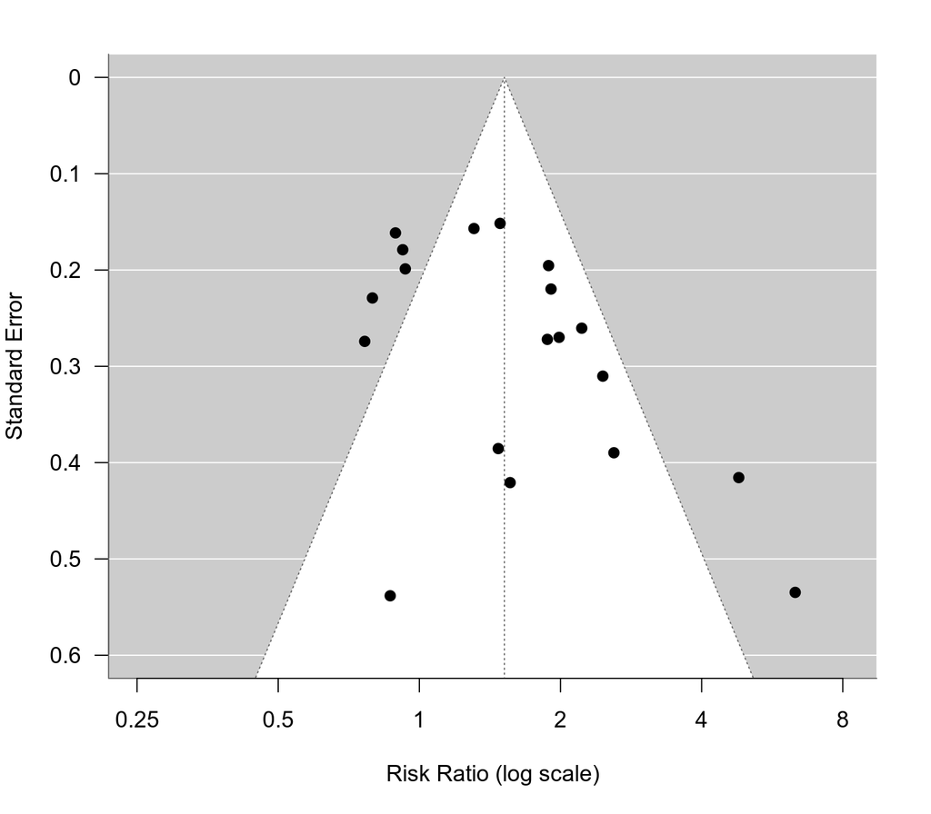

```r
# funnel plot

par(mar=c(5,4,2,2))
funnel(res, atransf=exp, at=log(c(0.25, 0.5, 1, 2, 4, 8)),
       ylim=c(0,0.6), steps=7, las=1)
```

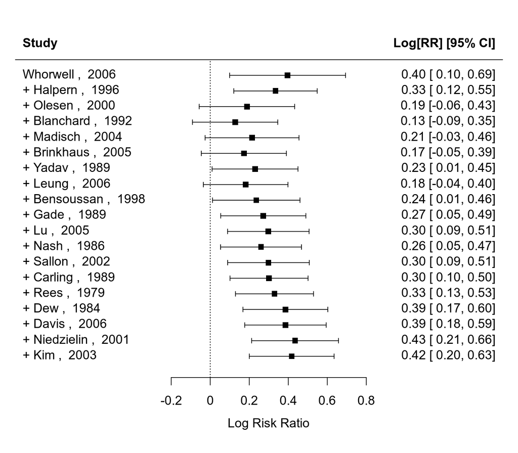

```r
# cumulative meta-analysis (in order of precision) and corresponding forest plot

sav <- cumul(res, order=vi)
par(mar=c(5,4,2,2))
forest(sav, header=TRUE, xlim=c(-1,1.5))
```

An alternative way of plotting the results from such a cumulative meta-analysis is to plot the pooled estimates (in this case, the estimated average log risk ratios) against the estimates of the amount of heterogeneity as studies are added. The color gradient of the points/lines indicates the order of the cumulative results (light gray at the beginning, dark gray at the end).

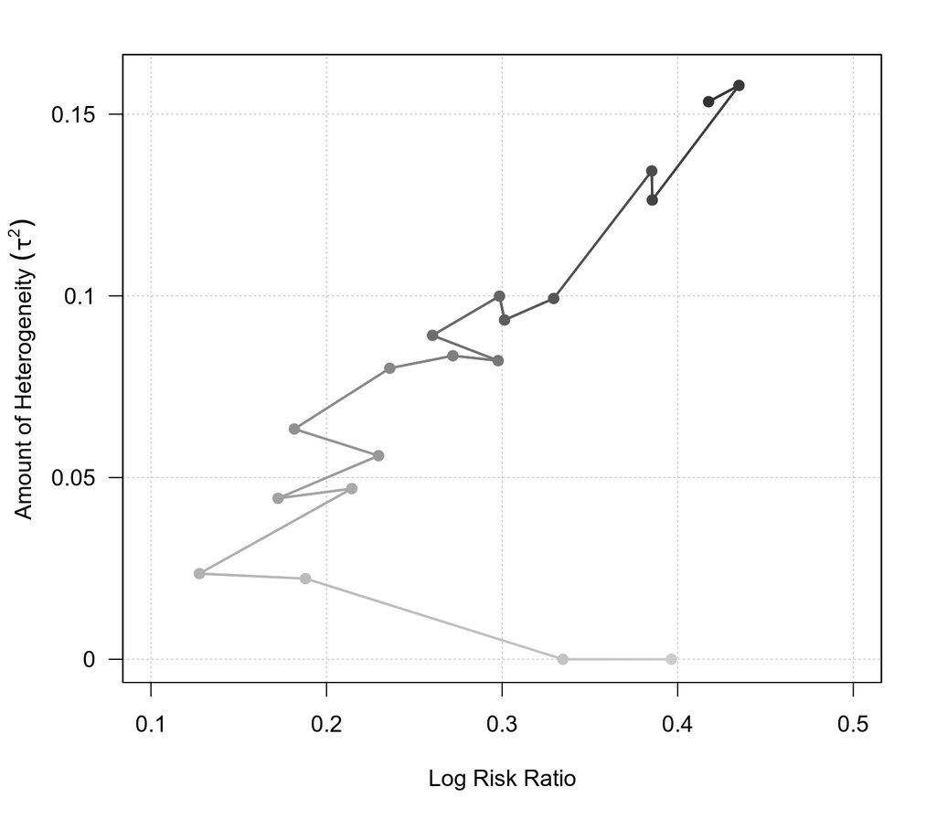

```r
# plot cumulative meta-analysis results

par(mar=c(5,4,2,2))
plot(sav, xlim=c(0.1,0.5), ylim=c(0,0.16), las=1)
```

```r
# trim and fill analysis

tf.l.l0 <- trimfill(res, side="left",  estimator="L0")
tf.l.r0 <- trimfill(res, side="left",  estimator="R0")
tf.r.l0 <- trimfill(res, side="right", estimator="L0")
tf.r.r0 <- trimfill(res, side="right", estimator="R0")

# show results for side="left" and estimator="R0"

tf.l.r0
```

```
## Estimated number of missing studies on the left side: 1 (SE = 2.00)
## Test of H0: no missing studies on the left side:      p-val = 0.25
##
## Random-Effects Model (k = 20; tau^2 estimator: ML)
##
## tau^2 (estimated amount of total heterogeneity): 0.18 (SE = 0.08)
## tau (square root of estimated tau^2 value):      0.43
## I^2 (total heterogeneity / total variability):   75.56%
## H^2 (total variability / sampling variability):  4.09
##
## Test for Heterogeneity:
## Q(df = 19) = 69.35, p-val < .01
##
## Model Results:
##
## estimate    se  zval  pval  ci.lb  ci.ub
##     0.38  0.12  3.26  <.01   0.15   0.61  **
##
## ---
## Signif. codes:  0 '***' 0.001 '**' 0.01 '*' 0.05 '.' 0.1 ' ' 1
```

```r
# Egger regression using a weighted regression model with the standard error as predictor

regtest(res, model="lm")
```

```
## Regression Test for Funnel Plot Asymmetry
##
## Model:     weighted regression with multiplicative dispersion
## Predictor: standard error
##
## Test for Funnel Plot Asymmetry: t =  2.22, df = 17, p = 0.04
## Limit Estimate (as sei -> 0):   b = -0.23 (CI: -0.78, 0.32)
```

```r
# Egger regression using a meta-regression model with the standard error as predictor

regtest(res)
```

```
## Regression Test for Funnel Plot Asymmetry
##
## Model:     mixed-effects meta-regression model
## Predictor: standard error
##
## Test for Funnel Plot Asymmetry: z =  2.64, p < .01
## Limit Estimate (as sei -> 0):   b = -0.23 (CI: -0.72, 0.27)
```

```r
# The PET-PEESE procedure is this: Start with Egger regression using a weighted regression
# model with the standard error as predictor. If the limit estimate (i.e., intercept) is not
# significant, the adjusted estimate is the limit estimate. On the other hand, if the limit
# estimate is significant, repeat the Egger regression but using the sampling variances as
# predictor. The adjusted estimate is then the limit estimate from that model.

regtest(res, model="lm", ret.fit=TRUE)
```

```
## Regression Test for Funnel Plot Asymmetry
##
## Model:     weighted regression with multiplicative dispersion
## Predictor: standard error
##
## Call:
## lm(formula = yi ~ X - 1, weights = 1/vi)
##
## Weighted Residuals:
##     Min      1Q  Median      3Q     Max
## -2.5967 -1.6355  0.6988  1.4555  1.9691
##
## Coefficients:
##          Estimate Std. Error t value Pr(>|t|)
## Xintrcpt  -0.2313     0.2612  -0.885   0.3883
## Xsei       2.4617     1.1087   2.220   0.0403 *
## ---
## Signif. codes:  0 '***' 0.001 '**' 0.01 '*' 0.05 '.' 0.1 ' ' 1
##
## Residual standard error: 1.687 on 17 degrees of freedom
## Multiple R-squared:  0.4949, Adjusted R-squared:  0.4355
## F-statistic: 8.329 on 2 and 17 DF,  p-value: 0.00301
##
## Test for Funnel Plot Asymmetry: t =  2.22, df = 17, p = 0.04
## Limit Estimate (as sei -> 0):   b = -0.23 (CI: -0.78, 0.32)
```

```r
# note: since the intercept is not significant (p = .39), the adjusted estimate is the limit
# estimate; but just for illustration purposes, if the intercept had been significant, then
# the adjusted estimate would be the limit estimate from the following model

regtest(res, model="lm", predictor="vi")
```

```
## Regression Test for Funnel Plot Asymmetry
##
## Model:     weighted regression with multiplicative dispersion
## Predictor: sampling variance
##
## Test for Funnel Plot Asymmetry: t = 2.13, df = 17, p = 0.05
## Limit Estimate (as vi -> 0):    b = 0.09 (CI: -0.20, 0.38)
```

```r
# rank correlation test

ranktest(res)
```

```
## Rank Correlation Test for Funnel Plot Asymmetry
##
## Kendall's tau = 0.26, p = 0.12
```

For a p-curve analysis, one needs to use the online app at http://p-curve.com/.

```r
# install the 'puniform' package (if it is not already installed) and load it

if (!require(puniform)) {
   install.packages("puniform")
   library(puniform)
}
```

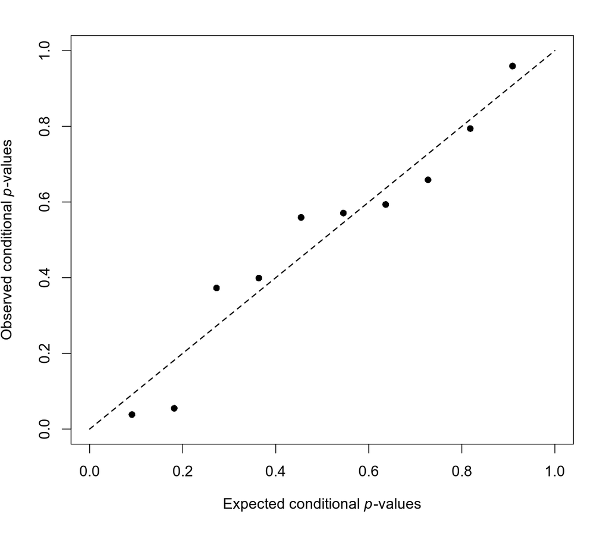

```
##
## Method: P
##
## Effect size estimation p-uniform
##
##        est     ci.lb     ci.ub       L.0    pval      ksig
##     0.6439    0.4067    0.9005     -4.03   <.001        10
##
## ===
##
## Publication bias test p-uniform
##
##       L.pb      pval
##    -2.6085    0.9955
##
## ===
##
## Fixed-effect meta-analysis
##
##     est.fe     se.fe   zval.fe pval.fe  ci.lb.fe  ci.ub.fe     Qstat   Qpval
##     0.3123    0.0541     5.777   <.001    0.2063    0.4182   62.4013   <.001
```

```r
# p-uniform

par(mar=c(5,4,2,2))
puniform(yi=dat$yi, vi=dat$vi, side="right", plot=TRUE)
```

```r
# excess significance test

tes(yi, vi, data=dat)
```

```
## Test of Excess Significance
##
## Observed Number of Significant Findings: 10 (out of 19)
## Expected Number of Significant Findings: 4.9233
## Observed Number / Expected Number:       2.0311
##
## Estimated Power of Tests (based on theta = 0.3123)
##
##    min      q1  median      q3     max
## 0.0894  0.1270  0.2118  0.3537  0.5397
##
## Test of Excess Significance: p = 0.0078 (exact test)
## Limit Estimate (theta_lim):  0.3971 (where p = 0.1)
```

```r
# install the 'selectMeta' package (if it is not already installed) and load it

if (!require(selectMeta)) {
   install.packages("selectMeta")
   library(selectMeta)
}
```

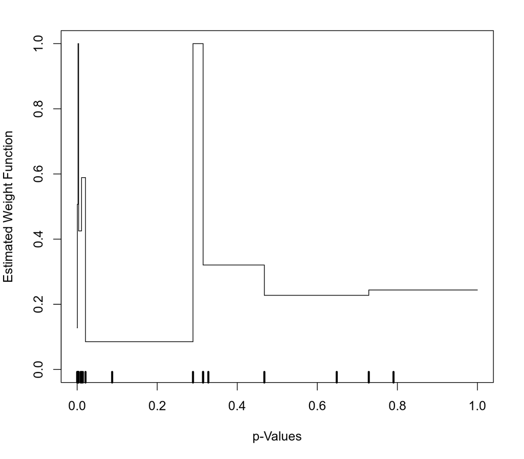

```r
# Dear and Begg weight-function model

sav <- DearBegg(dat$yi, sqrt(dat$vi), trace=FALSE)

par(mar=c(5,4,2,2))
plot(0, 0, type="n", xlim=c(0, 1), ylim=c(0, 1), xlab="p-Values", ylab="Estimated Weight Function")
ps <- seq(0, 1, by = 0.01)
pval <- summary(dat)$pval
rug(pval, lwd=3)
weightLine(pval, w=sav$w, col0="black", lwd0=1, lty0="solid")
```

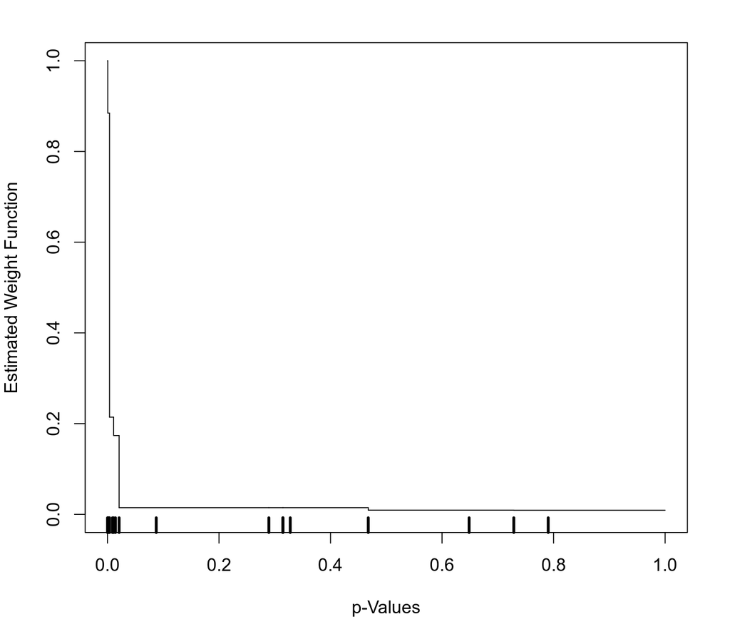

```r
# Rufibach weight-function model

sav <- DearBeggMonotone(dat$yi, sqrt(dat$vi), trace=FALSE)

par(mar=c(5,4,2,2))
plot(0, 0, type="n", xlim=c(0, 1), ylim=c(0, 1), xlab="p-Values", ylab="Estimated Weight Function")
ps <- seq(0, 1, by = 0.01)
pval <- summary(dat)$pval
rug(pval, lwd=3)
weightLine(pval, w=sav$w, col0="black", lwd0=1, lty0="solid")
```

```r
# Vevea and Hedges (1995) model (with a single cutpoint at p=0.025)

selmodel(res, type="stepfun", steps=0.025)
```

```
## Random-Effects Model (k = 19; tau^2 estimator: ML)
##
## tau^2 (estimated amount of total heterogeneity): 0.09 (SE = 0.07)
## tau (square root of estimated tau^2 value):      0.31
##
## Test for Heterogeneity:
## LRT(df = 1) = 6.10, p-val = 0.01
##
## Model Results:
##
## estimate    se  zval  pval  ci.lb  ci.ub
##     0.16  0.15  1.01  0.31  -0.14   0.45
##
## Test for Selection Model Parameters:
## LRT(df = 1) = 3.59, p-val = 0.06
##
## Selection Model Results:
##
##                      k  estimate    se   zval  pval  ci.lb  ci.ub
## 0     < p <= 0.025  10      1.00   ---    ---   ---    ---    ---
## 0.025 < p <= 1       9      0.19  0.18  -4.57  <.01   0.00   0.54  ***
##
## ---
## Signif. codes:  0 '***' 0.001 '**' 0.01 '*' 0.05 '.' 0.1 ' ' 1
```

```r
# Table 18.1: Sample Selection Patterns for the Vevea and Woods Method

ssp <- data.frame(
 steps = c(0.005, 0.01, 0.05, 0.10, 0.25, 0.35, 0.50, 0.65, 0.75, 0.90, 0.95, 0.99, 0.995, 1),
 weights.mod.1 = c(1, 0.99, 0.95, 0.80, 0.75, 0.65, 0.60, 0.55, 0.50, 0.50, 0.50, 0.50, 0.50, 0.50),
 weights.sev.1 = c(1, 0.99, 0.90, 0.75, 0.60, 0.50, 0.40, 0.35, 0.30, 0.25, 0.10, 0.10, 0.10, 0.10),
 weights.mod.2 = c(1, 0.99, 0.95, 0.90, 0.80, 0.75, 0.60, 0.60, 0.75, 0.80, 0.90, 0.95, 0.99, 1.00),
 weights.sev.2 = c(1, 0.99, 0.90, 0.75, 0.60, 0.50, 0.25, 0.25, 0.50, 0.60, 0.75, 0.90, 0.99, 1.00))
ssp
```

```
##    steps weights.mod.1 weights.sev.1 weights.mod.2 weights.sev.2
## 1  0.005          1.00          1.00          1.00          1.00
## 2  0.010          0.99          0.99          0.99          0.99
## 3  0.050          0.95          0.90          0.95          0.90
## 4  0.100          0.80          0.75          0.90          0.75
## 5  0.250          0.75          0.60          0.80          0.60
## 6  0.350          0.65          0.50          0.75          0.50
## 7  0.500          0.60          0.40          0.60          0.25
## 8  0.650          0.55          0.35          0.60          0.25
## 9  0.750          0.50          0.30          0.75          0.50
## 10 0.900          0.50          0.25          0.80          0.60
## 11 0.950          0.50          0.10          0.90          0.75
## 12 0.990          0.50          0.10          0.95          0.90
## 13 0.995          0.50          0.10          0.99          0.99
## 14 1.000          0.50          0.10          1.00          1.00
```

```r
# Vevea and Wood (2005) model using moderate one-tailed selection

selmodel(res, type="stepfun", steps=ssp$steps, delta=ssp$weights.mod.1)
```

```
## Random-Effects Model (k = 19; tau^2 estimator: ML)
##
## tau^2 (estimated amount of total heterogeneity): 0.16 (SE = 0.09)
## tau (square root of estimated tau^2 value):      0.40
##
## Test for Heterogeneity:
## LRT(df = 1) = 17.74, p-val < .01
##
## Model Results:
##
## estimate    se  zval  pval  ci.lb  ci.ub
##     0.31  0.12  2.61  <.01   0.08   0.54  **
##
## Test for Selection Model Parameters:
## LRT(df = 0) = 0.00, p-val = NA
##
## Selection Model Results:
##
##                     k  estimate   se  zval  pval  ci.lb  ci.ub
## 0     < p <= 0.005  7      1.00  ---   ---   ---    ---    ---
## 0.005 < p <= 0.01   2      0.99  ---   ---   ---    ---    ---
## 0.01  < p <= 0.05   2      0.95  ---   ---   ---    ---    ---
## 0.05  < p <= 0.1    0      0.80  ---   ---   ---    ---    ---
## 0.1   < p <= 0.25   2      0.75  ---   ---   ---    ---    ---
## 0.25  < p <= 0.35   0      0.65  ---   ---   ---    ---    ---
## 0.35  < p <= 0.5    0      0.60  ---   ---   ---    ---    ---
## 0.5   < p <= 0.65   2      0.55  ---   ---   ---    ---    ---
## 0.65  < p <= 0.75   1      0.50  ---   ---   ---    ---    ---
## 0.75  < p <= 0.9    3      0.50  ---   ---   ---    ---    ---
## 0.9   < p <= 0.95   0      0.50  ---   ---   ---    ---    ---
## 0.95  < p <= 0.99   0      0.50  ---   ---   ---    ---    ---
## 0.99  < p <= 0.995  0      0.50  ---   ---   ---    ---    ---
## 0.995 < p <= 1      0      0.50  ---   ---   ---    ---    ---
##
## ---
## Signif. codes:  0 '***' 0.001 '**' 0.01 '*' 0.05 '.' 0.1 ' ' 1
```

```r
# Vevea and Wood (2005) model using severe one-tailed selection

selmodel(res, type="stepfun", steps=ssp$steps, delta=ssp$weights.sev.1)
```

```
## Random-Effects Model (k = 19; tau^2 estimator: ML)
##
## tau^2 (estimated amount of total heterogeneity): 0.23 (SE = 0.14)
## tau (square root of estimated tau^2 value):      0.48
##
## Test for Heterogeneity:
## LRT(df = 1) = 19.45, p-val < .01
##
## Model Results:
##
## estimate    se  zval  pval  ci.lb  ci.ub
##     0.11  0.18  0.57  0.57  -0.26   0.47
##
## Test for Selection Model Parameters:
## LRT(df = 0) = 0.66, p-val = NA
##
## Selection Model Results:
##
##                     k  estimate   se  zval  pval  ci.lb  ci.ub
## 0     < p <= 0.005  7      1.00  ---   ---   ---    ---    ---
## 0.005 < p <= 0.01   2      0.99  ---   ---   ---    ---    ---
## 0.01  < p <= 0.05   2      0.90  ---   ---   ---    ---    ---
## 0.05  < p <= 0.1    0      0.75  ---   ---   ---    ---    ---
## 0.1   < p <= 0.25   2      0.60  ---   ---   ---    ---    ---
## 0.25  < p <= 0.35   0      0.50  ---   ---   ---    ---    ---
## 0.35  < p <= 0.5    0      0.40  ---   ---   ---    ---    ---
## 0.5   < p <= 0.65   2      0.35  ---   ---   ---    ---    ---
## 0.65  < p <= 0.75   1      0.30  ---   ---   ---    ---    ---
## 0.75  < p <= 0.9    3      0.25  ---   ---   ---    ---    ---
## 0.9   < p <= 0.95   0      0.10  ---   ---   ---    ---    ---
## 0.95  < p <= 0.99   0      0.10  ---   ---   ---    ---    ---
## 0.99  < p <= 0.995  0      0.10  ---   ---   ---    ---    ---
## 0.995 < p <= 1      0      0.10  ---   ---   ---    ---    ---
##
## ---
## Signif. codes:  0 '***' 0.001 '**' 0.01 '*' 0.05 '.' 0.1 ' ' 1
```

```r
# Vevea and Wood (2005) model using moderate two-tailed selection

selmodel(res, type="stepfun", steps=ssp$steps, delta=ssp$weights.mod.2)
```

```
## Random-Effects Model (k = 19; tau^2 estimator: ML)
##
## tau^2 (estimated amount of total heterogeneity): 0.14 (SE = 0.07)
## tau (square root of estimated tau^2 value):      0.37
##
## Test for Heterogeneity:
## LRT(df = 1) = 16.73, p-val < .01
##
## Model Results:
##
## estimate    se  zval  pval  ci.lb  ci.ub
##     0.37  0.11  3.52  <.01   0.16   0.58  ***
##
## Test for Selection Model Parameters:
## LRT(df = 0) = 0.24, p-val = NA
##
## Selection Model Results:
##
##                     k  estimate   se  zval  pval  ci.lb  ci.ub
## 0     < p <= 0.005  7      1.00  ---   ---   ---    ---    ---
## 0.005 < p <= 0.01   2      0.99  ---   ---   ---    ---    ---
## 0.01  < p <= 0.05   2      0.95  ---   ---   ---    ---    ---
## 0.05  < p <= 0.1    0      0.90  ---   ---   ---    ---    ---
## 0.1   < p <= 0.25   2      0.80  ---   ---   ---    ---    ---
## 0.25  < p <= 0.35   0      0.75  ---   ---   ---    ---    ---
## 0.35  < p <= 0.5    0      0.60  ---   ---   ---    ---    ---
## 0.5   < p <= 0.65   2      0.60  ---   ---   ---    ---    ---
## 0.65  < p <= 0.75   1      0.75  ---   ---   ---    ---    ---
## 0.75  < p <= 0.9    3      0.80  ---   ---   ---    ---    ---
## 0.9   < p <= 0.95   0      0.90  ---   ---   ---    ---    ---
## 0.95  < p <= 0.99   0      0.95  ---   ---   ---    ---    ---
## 0.99  < p <= 0.995  0      0.99  ---   ---   ---    ---    ---
## 0.995 < p <= 1      0      1.00  ---   ---   ---    ---    ---
##
## ---
## Signif. codes:  0 '***' 0.001 '**' 0.01 '*' 0.05 '.' 0.1 ' ' 1
```

```r
# Vevea and Wood (2005) model using severe two-tailed selection

selmodel(res, type="stepfun", steps=ssp$steps, delta=ssp$weights.sev.2)
```

```
## Random-Effects Model (k = 19; tau^2 estimator: ML)
##
## tau^2 (estimated amount of total heterogeneity): 0.11 (SE = 0.06)
## tau (square root of estimated tau^2 value):      0.34
##
## Test for Heterogeneity:
## LRT(df = 1) = 14.29, p-val < .01
##
## Model Results:
##
## estimate    se  zval  pval  ci.lb  ci.ub
##     0.32  0.10  3.30  <.01   0.13   0.51  ***
##
## Test for Selection Model Parameters:
## LRT(df = 0) = 0.00, p-val = NA
##
## Selection Model Results:
##
##                     k  estimate   se  zval  pval  ci.lb  ci.ub
## 0     < p <= 0.005  7      1.00  ---   ---   ---    ---    ---
## 0.005 < p <= 0.01   2      0.99  ---   ---   ---    ---    ---
## 0.01  < p <= 0.05   2      0.90  ---   ---   ---    ---    ---
## 0.05  < p <= 0.1    0      0.75  ---   ---   ---    ---    ---
## 0.1   < p <= 0.25   2      0.60  ---   ---   ---    ---    ---
## 0.25  < p <= 0.35   0      0.50  ---   ---   ---    ---    ---
## 0.35  < p <= 0.5    0      0.25  ---   ---   ---    ---    ---
## 0.5   < p <= 0.65   2      0.25  ---   ---   ---    ---    ---
## 0.65  < p <= 0.75   1      0.50  ---   ---   ---    ---    ---
## 0.75  < p <= 0.9    3      0.60  ---   ---   ---    ---    ---
## 0.9   < p <= 0.95   0      0.75  ---   ---   ---    ---    ---
## 0.95  < p <= 0.99   0      0.90  ---   ---   ---    ---    ---
## 0.99  < p <= 0.995  0      0.99  ---   ---   ---    ---    ---
## 0.995 < p <= 1      0      1.00  ---   ---   ---    ---    ---
##
## ---
## Signif. codes:  0 '***' 0.001 '**' 0.01 '*' 0.05 '.' 0.1 ' ' 1
```

```r
# install the 'metasens' package (if it is not already installed) and load it

if (!require(metasens)) {
   install.packages("metasens")
   library(metasens)
}
```

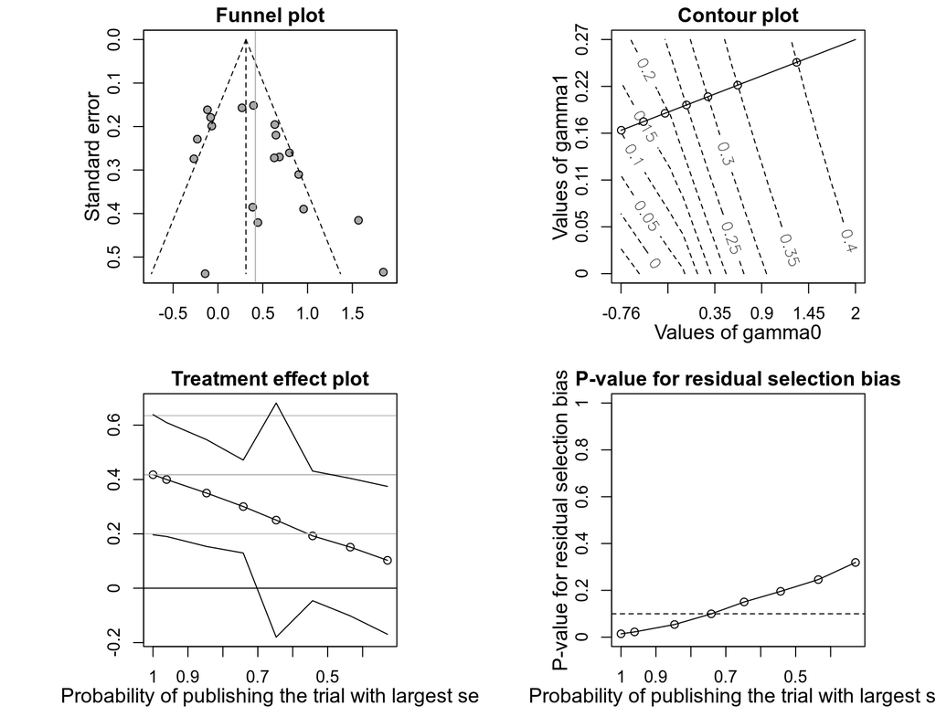

```r
# Copas and Shi (2001) model

res <- metagen(yi, sqrt(vi), method.tau="ML", data=dat)
sav <- copas(res)
plot(sav)
```

```r
summary(sav)
```

```
## Copas selection model analysis
##
##               p.publ                   95%-CI  tau^2    tau  p.trt  p.rsb  N
##               1.0000 0.4176 [ 0.1966; 0.6386] 0.1534 0.3917 0.0002 0.0144  0
##               0.9612 0.3999 [ 0.1903; 0.6095] 0.1391 0.3729 0.0002 0.0225  0
##               0.8468 0.3501 [ 0.1535; 0.5466] 0.1197 0.3460 0.0005 0.0541  2
##               0.7417 0.3004 [ 0.1295; 0.4714] 0.1117 0.3342 0.0006 0.0997  3
##               0.6475 0.2506 [-0.1802; 0.6813] 0.1097 0.3313 0.2542 0.1504  6
##               0.5432 0.1925 [-0.0460; 0.4310] 0.1115 0.3339 0.1137 0.1957  9
##               0.4352 0.1511 [-0.1019; 0.4041] 0.1083 0.3291 0.2418 0.2460 15
##               0.3288 0.1026 [-0.1695; 0.3746] 0.1047 0.3236 0.4599 0.3191 24
##
##    Adjusted estimate 0.2506 [-0.1802; 0.6813] 0.1097 0.3313 0.2542 0.1504  6
##  Unadjusted estimate 0.4176 [ 0.2003; 0.6348] 0.1534 0.3917 0.0002
##
## Significance level for test of residual selection bias: 0.1
##
##                        min    max
##  range of gamma0:  -0.7558 2.0000
##  range of gamma1:   0.0000 0.2723
##
## Largest standard error (SE): 0.5383
##
## Range of probability publishing trial with largest SE:
##     min    max
##  0.2249 0.9939
##
## Calculation of orthogonal line:
##
##  level nobs adj.r.square     slope    se.slope
##  -0.05    5    0.9999830 -1.362614 0.002809321
##   0.00    9    0.9998969 -1.440954 0.005173595
##   0.05   14    0.9994926 -1.513392 0.009457356
##   0.10   19    0.9925764 -1.774954 0.036173183
##   0.15   24    0.9886879 -2.100479 0.046836982
##   0.20   28    0.9914366 -2.508877 0.044866233
##   0.25   26    0.9997682 -2.980742 0.009078334
##   0.30   26    0.9995475 -3.081597 0.013113046
##   0.35   26    0.9993143 -3.196848 0.016748454
##   0.40   24    0.9990672 -3.426336 0.021830322
##
##  Legend:
##  p.publ - Probability of publishing study with largest SE
##  p.trt  - P-value for test of overall treatment effect
##  p.rsb  - P-value for test of residual selection bias
##  N      - Estimated number of unpublished studies
```

```r
# Rücker limit meta-analysis

sav <- limitmeta(res)
sav
```

```
## Result of limit meta-analysis:
##
##  Random effects model                   95%-CI    z   pval
##     Adjusted estimate 0.0854 [-0.2800; 0.4508] 0.46 0.6469
##   Unadjusted estimate 0.4176 [ 0.2003; 0.6348] 3.77 0.0002
##
## Quantifying heterogeneity:
## tau^2 = 0.1534; I^2 = 71.2% [54.1%; 81.9%]; G^2 = 99.9%
##
## Test of heterogeneity:
##      Q d.f.  p-value
##  62.40   18 < 0.0001
##
## Test of small-study effects:
##   Q-Q' d.f.  p-value
##  14.03    1   0.0002
##
## Test of residual heterogeneity beyond small-study effects:
##     Q' d.f.  p-value
##  48.37   17 < 0.0001
##
## Details on adjustment method:
## - expectation (beta0)
```

## 19) Interpreting Effect Sizes

```r
# converting d-values to U1, U2, and U3

transf.dtou1(1.0)
```

```
## [1] 0.5537899
```

```r
transf.dtou2(1.0)
```

```
## [1] 0.6914625
```

```r
transf.dtou3(1.0)
```

```
## [1] 0.8413447
```

```r
# converting d-values to common language effect size values

transf.dtocles(0.3)
```

```
## [1] 0.583998
```

```r
# converting d-values to binomial effect-size display values

transf.dtobesd(0.3)
```

```
## [1] 0.5741702
```

```r
# note: this is the proportion in the first group scoring above the median; the proportion
# in the second group scoring above the median is simply 1 minus the computed value:

1 - transf.dtobesd(0.3)
```

```
## [1] 0.4258298
```

```r
# converting a 2x2 table to a correlation (phi coefficient)

escalc(measure="PHI", ai=100, bi=50, ci=60, di=90)
```

```
##       yi     vi
## 1 0.2673 0.0031
```

```r
# converting a 2x2 table to an odds ratio

summary(escalc(measure="OR", ai=100, bi=50, ci=60, di=90), transf=exp)
```

```
##       yi  ci.lb  ci.ub
## 1 3.0000 1.8729 4.8053
```

```r
# note: escalc(measure="OR", ...) computes log odds ratios, so need to exponentiate
```

```r
# converting a 2x2 table to a risk ratio

summary(escalc(measure="RR", ai=100, bi=50, ci=60, di=90), transf=exp)
```

```
##       yi  ci.lb  ci.ub
## 1 1.6667 1.3291 2.0900
```

```r
# note: escalc(measure="RR", ...) computes log risk ratios, so need to exponentiate
```

```r
# converting a 2x2 table to a risk difference

escalc(measure="RD", ai=100, bi=50, ci=60, di=90)
```

```
##       yi     vi
## 1 0.2667 0.0031
```

```r
# converting a 2x2 table to a number needed to treat

summary(escalc(measure="RD", ai=100, bi=50, ci=60, di=90), transf=function(x) 1/x)
```

```
##       yi  ci.lb  ci.ub
## 1 3.7500 2.6634 6.3344
```

```r
# using effect-size translations with confidence intervals (after a meta-analysis)

# note: using some made-up data that yield the same results as shown on page 443

# example with standardized mean differences

dat <- data.frame(di = c(0.03, 0.93, 0.66),
                  vi = c(0.072, 0.063, 0.047))
res <- rma(di, vi, data=dat, digits=2)
res
```

```
## Random-Effects Model (k = 3; tau^2 estimator: REML)
##
## tau^2 (estimated amount of total heterogeneity): 0.14 (SE = 0.20)
## tau (square root of estimated tau^2 value):      0.37
## I^2 (total heterogeneity / total variability):   69.70%
## H^2 (total variability / sampling variability):  3.30
##
## Test for Heterogeneity:
## Q(df = 2) = 6.28, p-val = 0.04
##
## Model Results:
##
## estimate    se  zval  pval  ci.lb  ci.ub
##     0.55  0.26  2.15  0.03   0.05   1.05  *
##
## ---
## Signif. codes:  0 '***' 0.001 '**' 0.01 '*' 0.05 '.' 0.1 ' ' 1
```

```r
predict(res, transf=transf.dtou3)
```

```
##  pred ci.lb ci.ub pi.lb pi.ub
##  0.71  0.52  0.85  0.37  0.92
```

```r
# example with (log) odds ratios

dat <- data.frame(logori = c(0.40, 0.74, 0.99, 0.84, 0.75),
                  vi = c(0.111, 0.093, 0.165, 0.128, 0.114))
res <- rma(logori, vi, data=dat, digits=3)
res
```

```
## Random-Effects Model (k = 5; tau^2 estimator: REML)
##
## tau^2 (estimated amount of total heterogeneity): 0 (SE = 0.083)
## tau (square root of estimated tau^2 value):      0
## I^2 (total heterogeneity / total variability):   0.00%
## H^2 (total variability / sampling variability):  1.00
##
## Test for Heterogeneity:
## Q(df = 4) = 1.488, p-val = 0.829
##
## Model Results:
##
## estimate     se   zval   pval  ci.lb  ci.ub
##    0.724  0.154  4.715  <.001  0.423  1.025  ***
##
## ---
## Signif. codes:  0 '***' 0.001 '**' 0.01 '*' 0.05 '.' 0.1 ' ' 1
```

```r
predict(res, transf=exp, digits=2)
```

```
##  pred ci.lb ci.ub pi.lb pi.ub
##  2.06  1.53  2.79  1.53  2.79
```

```r
predict(res, transf=function(x) transf.lnortord(x, pc=0.12), digits=2)
```

```
##  pred ci.lb ci.ub pi.lb pi.ub
##  0.10  0.05  0.16  0.05  0.16
```

See also the R functions provided by the chapter authors (Jeffrey Valentine, Ariel Aloe, and Sandra Wilson) at the end of the chapter. The code is also available on the publisher’s website for the book ([see here](https://www.russellsage.org/publications/handbook-research-synthesis-and-meta-analysis)).

## 20) Heterogeneity in Meta-Analysis

```r
# data for the illustrative example

dat <- data.frame(yi = seq(10, 90, by=10), vi = 562.5)
dat
```

```
##   yi    vi
## 1 10 562.5
## 2 20 562.5
## 3 30 562.5
## 4 40 562.5
## 5 50 562.5
## 6 60 562.5
## 7 70 562.5
## 8 80 562.5
## 9 90 562.5
```

```r
# fit random-effects model

res <- rma(yi, vi, data=dat, method="DL")
res
```

```
## Random-Effects Model (k = 9; tau^2 estimator: DL)
##
## tau^2 (estimated amount of total heterogeneity): 187.5000 (SE = 375.0000)
## tau (square root of estimated tau^2 value):      13.6931
## I^2 (total heterogeneity / total variability):   25.00%
## H^2 (total variability / sampling variability):  1.33
##
## Test for Heterogeneity:
## Q(df = 8) = 10.6667, p-val = 0.2213
##
## Model Results:
##
## estimate      se    zval    pval    ci.lb    ci.ub
##  50.0000  9.1287  5.4772  <.0001  32.1081  67.8919  ***
##
## ---
## Signif. codes:  0 '***' 0.001 '**' 0.01 '*' 0.05 '.' 0.1 ' ' 1
```

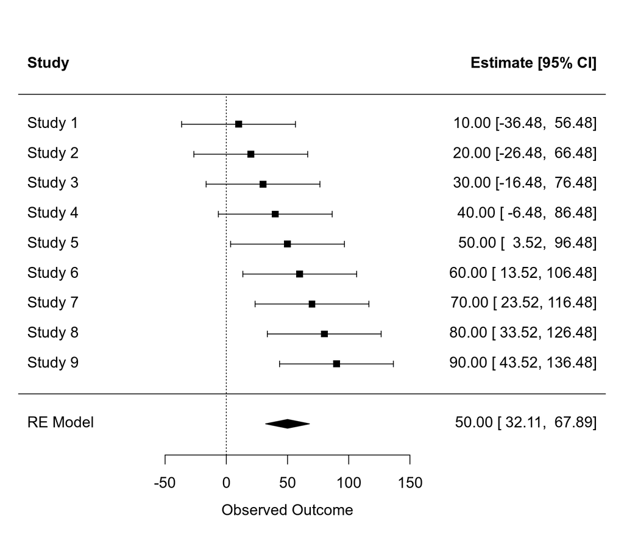

```r
# forest plot

par(mar=c(5,4,2,2))
forest(res, header=TRUE, xlim=c(-170, 310))
```

```r
# approximate 95% prediction interval (based on equation 20.6)

predict(res, pi.type="simple", digits=0)
```

```
##  pred se ci.lb ci.ub pi.lb pi.ub
##    50  9    32    68    23    77
```

```r
# approximate 95% prediction interval (based on equation 20.7)

predict(res, pi.type="riley", digits=0)
```

```
##  pred se ci.lb ci.ub pi.lb pi.ub
##    50  9    32    68    11    89
```

Note: The prediction interval is computed in a slightly different way in the book compared to how this is done (by default) in the `metafor` package. For more details, see [here](https://www.metafor-project.org/doku.php/faq#for_random-effects_models_fitt). However, by using argument `pi.type="riley"`, equation 20.7 is used.

```r
# data for Figure 20.3

dat <- read.table(header=TRUE, text = "
study   mean1 sd1  n1 mean2 sd2  n2
Carroll    94  22  60    92  20  60
Grant      98  21  65    92  22  65
Peck       98  28  40    88  26  40
Donat      94  19 200    82  17 200
Stewart    98  21  50    88  22  45
Young      96  21  85    92  22  85")

dat <- escalc("SMD", m1i=mean1, sd1i=sd1, n1i=n1, m2i=mean2, sd2i=sd2, n2i=n2,
              slab=study, data=dat, vtype="LS2")
dat
```

```
##     study mean1 sd1  n1 mean2 sd2  n2     yi     vi
## 1 Carroll    94  22  60    92  20  60 0.0945 0.0329
## 2   Grant    98  21  65    92  22  65 0.2774 0.0307
## 3    Peck    98  28  40    88  26  40 0.3665 0.0499
## 4   Donat    94  19 200    82  17 200 0.6644 0.0105
## 5 Stewart    98  21  50    88  22  45 0.4618 0.0427
## 6   Young    96  21  85    92  22  85 0.1852 0.0234
```

```r
# fit equal- and random-effects models

res.ee <- rma(yi, vi, data=dat, method="EE")
res.re <- rma(yi, vi, data=dat, method="DL")

# show random-effects model results
print(res.re, digits=3)
```

```
## Random-Effects Model (k = 6; tau^2 estimator: DL)
##
## tau^2 (estimated amount of total heterogeneity): 0.037 (SE = 0.042)
## tau (square root of estimated tau^2 value):      0.193
## I^2 (total heterogeneity / total variability):   58.34%
## H^2 (total variability / sampling variability):  2.40
##
## Test for Heterogeneity:
## Q(df = 5) = 12.003, p-val = 0.035
##
## Model Results:
##
## estimate     se   zval   pval  ci.lb  ci.ub
##    0.358  0.105  3.404  <.001  0.152  0.565  ***
##
## ---
## Signif. codes:  0 '***' 0.001 '**' 0.01 '*' 0.05 '.' 0.1 ' ' 1
```

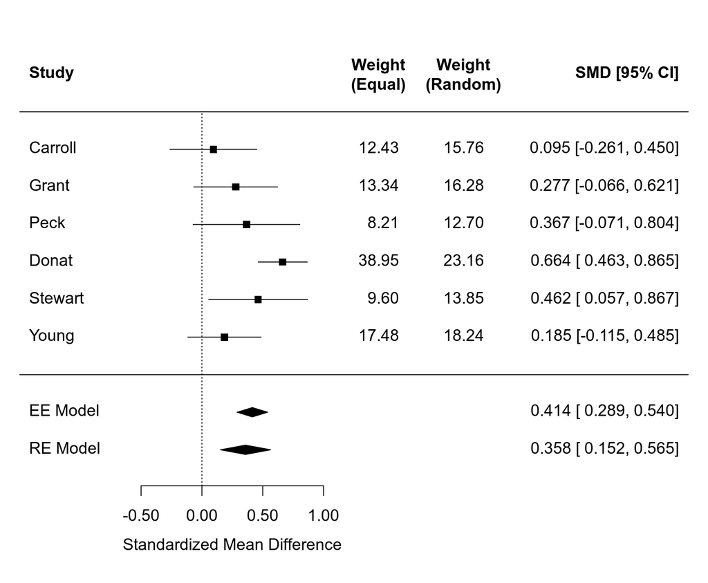

```r
# Figure 20.3: Meta-Analysis Showing Relative Weights for the Equal- and Random-Effects Models

wi <- fmtx(cbind(weights(res.ee), weights(res.re)), digits=2)

par(mar=c(5,4,2,2))
forest(res.ee, header=TRUE, xlim=c(-1.5,4), ylim=c(-2.5,9), psize=1, efac=c(0,1),
       ilab=wi, ilab.xpos=c(1.7,2.4), ilab.pos=2, digits=c(3,2))
addpoly(res.re)
text(1.45, 8, "Weight\n(Equal)",  font=2)
text(2.15, 8, "Weight\n(Random)", font=2)
```

## License

This documented is licensed under the following license: [CC Attribution-Noncommercial-Share Alike 4.0 International](http://creativecommons.org/licenses/by-nc-sa/4.0/).